# 10 minites

Jie Wang

12/1/2021

```r
airbnb<- read.csv("C:\\Users\\edwar\\Documents\\BMIS\\AB_NYC_2019.csv",header = T)
dim(airbnb)
```

```
## [1] 48895    16
```

```r
summary(airbnb)
```

```
##        id               name              host_id           host_name
##  Min.   :    2539   Length:48895       Min.   :     2438   Length:48895
##  1st Qu.: 9471945   Class :character   1st Qu.:  7822033   Class :character
##  Median :19677284   Mode  :character   Median : 30793816   Mode  :character
##  Mean   :19017143                      Mean   : 67620011
##  3rd Qu.:29152178                      3rd Qu.:107434423
##  Max.   :36487245                      Max.   :274321313
##
##  neighbourhood_group neighbourhood         latitude       longitude
##  Length:48895        Length:48895       Min.   :40.50   Min.   :-74.24
##  Class :character    Class :character   1st Qu.:40.69   1st Qu.:-73.98
##  Mode  :character    Mode  :character   Median :40.72   Median :-73.96
##                                         Mean   :40.73   Mean   :-73.95
##                                         3rd Qu.:40.76   3rd Qu.:-73.94
##                                         Max.   :40.91   Max.   :-73.71
##
##   room_type             price         minimum_nights    number_of_reviews
##  Length:48895       Min.   :    0.0   Min.   :   1.00   Min.   :  0.00
##  Class :character   1st Qu.:   69.0   1st Qu.:   1.00   1st Qu.:  1.00
##  Mode  :character   Median :  106.0   Median :   3.00   Median :  5.00
##                     Mean   :  152.7   Mean   :   7.03   Mean   : 23.27
##                     3rd Qu.:  175.0   3rd Qu.:   5.00   3rd Qu.: 24.00
##                     Max.   :10000.0   Max.   :1250.00   Max.   :629.00
##
##  last_review        reviews_per_month calculated_host_listings_count
##  Length:48895       Min.   : 0.010    Min.   :  1.000
##  Class :character   1st Qu.: 0.190    1st Qu.:  1.000
##  Mode  :character   Median : 0.720    Median :  1.000
##                     Mean   : 1.373    Mean   :  7.144
##                     3rd Qu.: 2.020    3rd Qu.:  2.000
##                     Max.   :58.500    Max.   :327.000
##                     NA's   :10052
##  availability_365
##  Min.   :  0.0
##  1st Qu.:  0.0
##  Median : 45.0
##  Mean   :112.8
##  3rd Qu.:227.0
##  Max.   :365.0
##
```

```r
sum(is.na(airbnb))
```

```
## [1] 10052
```

Visual representation of missing values

```r
# tabulate missing values patters
library(VIM)
library(mice)
```

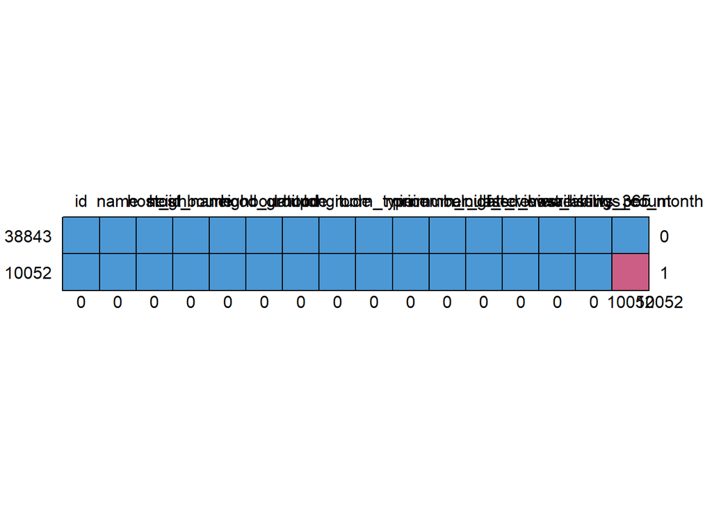

```
##       id name host_id host_name neighbourhood_group neighbourhood latitude
## 38843  1    1       1         1                   1             1        1
## 10052  1    1       1         1                   1             1        1
##        0    0       0         0                   0             0        0
##       longitude room_type price minimum_nights number_of_reviews last_review
## 38843         1         1     1              1                 1           1
## 10052         1         1     1              1                 1           1
##               0         0     0              0                 0           0
##       calculated_host_listings_count availability_365 reviews_per_month
## 38843                              1                1                 1     0
## 10052                              1                1                 0     1
##                                    0                0             10052 10052
```

```r
md.pattern(airbnb)
```

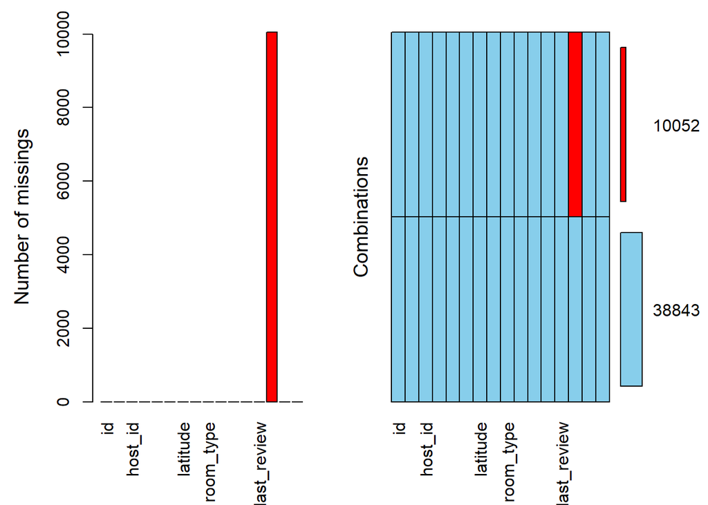

```r
# plot missing values patterns
aggr(airbnb, prop=FALSE, numbers=TRUE)
```

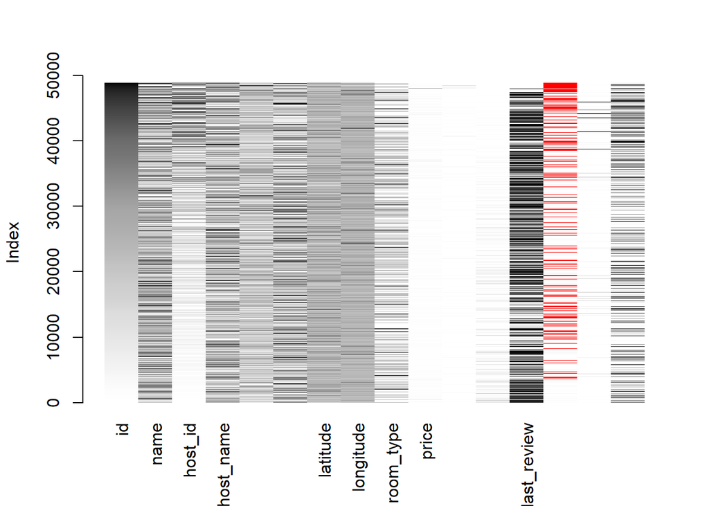

```r
matrixplot(airbnb)
```

It seems like all the missing values come from variable “reviews_per_month”. Since we already have the similar information from variable “number_of _reviews”, we can just simply drop this variable.

```r
library(dplyr)
airbnb<-data.frame(airbnb)
airbnb1<-select(airbnb,-reviews_per_month) # drop the unwanted column
dim(airbnb1)
```

```
## [1] 48895    15
```

```r
sum(is.na(airbnb1))
```

```
## [1] 0
```

```r
summary(airbnb1)
```

```
##        id               name              host_id           host_name
##  Min.   :    2539   Length:48895       Min.   :     2438   Length:48895
##  1st Qu.: 9471945   Class :character   1st Qu.:  7822033   Class :character
##  Median :19677284   Mode  :character   Median : 30793816   Mode  :character
##  Mean   :19017143                      Mean   : 67620011
##  3rd Qu.:29152178                      3rd Qu.:107434423
##  Max.   :36487245                      Max.   :274321313
##  neighbourhood_group neighbourhood         latitude       longitude
##  Length:48895        Length:48895       Min.   :40.50   Min.   :-74.24
##  Class :character    Class :character   1st Qu.:40.69   1st Qu.:-73.98
##  Mode  :character    Mode  :character   Median :40.72   Median :-73.96
##                                         Mean   :40.73   Mean   :-73.95
##                                         3rd Qu.:40.76   3rd Qu.:-73.94
##                                         Max.   :40.91   Max.   :-73.71
##   room_type             price         minimum_nights    number_of_reviews
##  Length:48895       Min.   :    0.0   Min.   :   1.00   Min.   :  0.00
##  Class :character   1st Qu.:   69.0   1st Qu.:   1.00   1st Qu.:  1.00
##  Mode  :character   Median :  106.0   Median :   3.00   Median :  5.00
##                     Mean   :  152.7   Mean   :   7.03   Mean   : 23.27
##                     3rd Qu.:  175.0   3rd Qu.:   5.00   3rd Qu.: 24.00
##                     Max.   :10000.0   Max.   :1250.00   Max.   :629.00
##  last_review        calculated_host_listings_count availability_365
##  Length:48895       Min.   :  1.000                Min.   :  0.0
##  Class :character   1st Qu.:  1.000                1st Qu.:  0.0
##  Mode  :character   Median :  1.000                Median : 45.0
##                     Mean   :  7.144                Mean   :112.8
##                     3rd Qu.:  2.000                3rd Qu.:227.0
##                     Max.   :327.000                Max.   :365.0
```

Now, we successfully drop the column containing all missing values, and the data set is clean and ready to be analyzed.

```r
# another way to drop a column and calculate the percentage
# Remove variable "reviews_per_month"
airbnb_Var_dropped <- airbnb # Create a new temporary dataframe
airbnb_Var_dropped$reviews_per_month <- NULL


airbnb_Missing_dropped <- na.omit(airbnb_Var_dropped)
Dropped_percent <- (nrow(airbnb_Var_dropped) - nrow(airbnb_Missing_dropped))/nrow(airbnb_Var_dropped)
Dropped_percent
```

```
## [1] 0
```

Since we delete the whole column, we don’t lose any data points.

Now, let’s do some visual analysis.

#### Data Visualization: Plotting

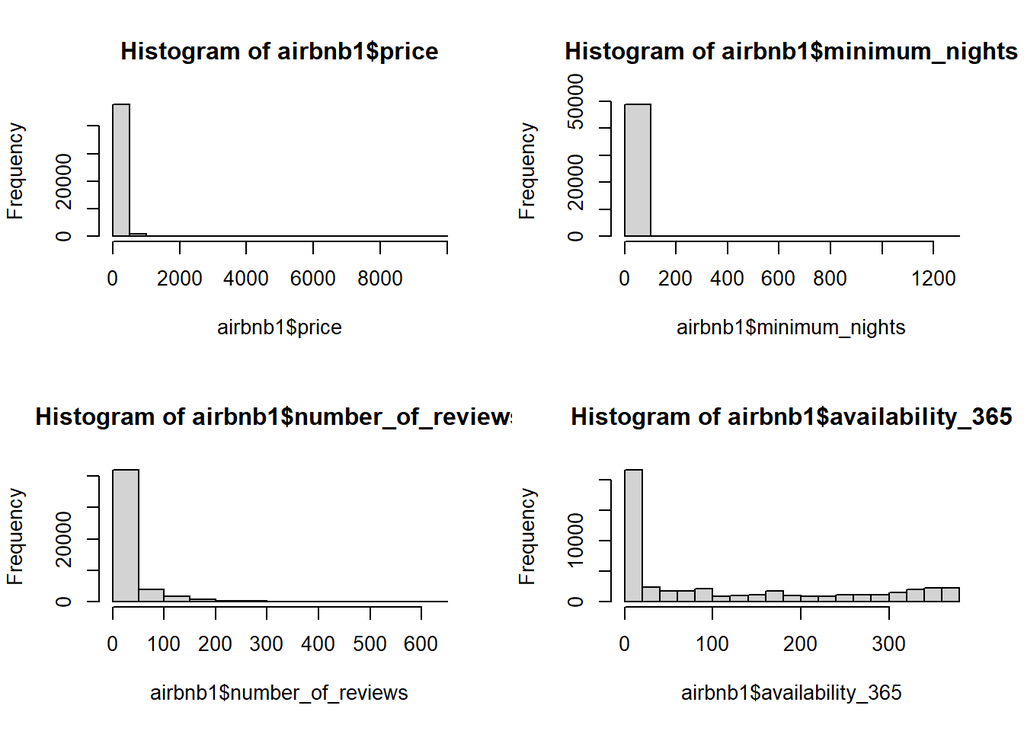

```r
par(mfrow=c(2,2))
library(ggplot2)
hist(airbnb1$price)
hist(airbnb1$minimum_nights)
hist(airbnb1$number_of_reviews)
hist(airbnb1$availability_365)
```

All 4 variables are right skewed. Transformation may needed but hard to interpret. Another way is to transfer to categorical variables.

The ggplot base container:

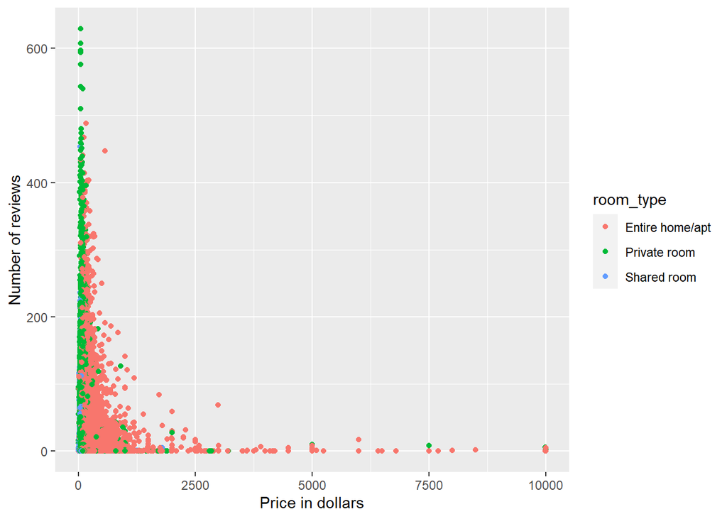

```r
library(ggplot2)
#Scatter plot:

ggplot(data = airbnb1) +
  geom_point(mapping = aes(x = price, y = number_of_reviews, color = room_type)) +
    labs(x = "Price in dollars", y = "Number of reviews")
```

We can see that the number of reviews decreases with the increase of price. This may due to the reason that expensive airbnbs is not affordable for most customers.

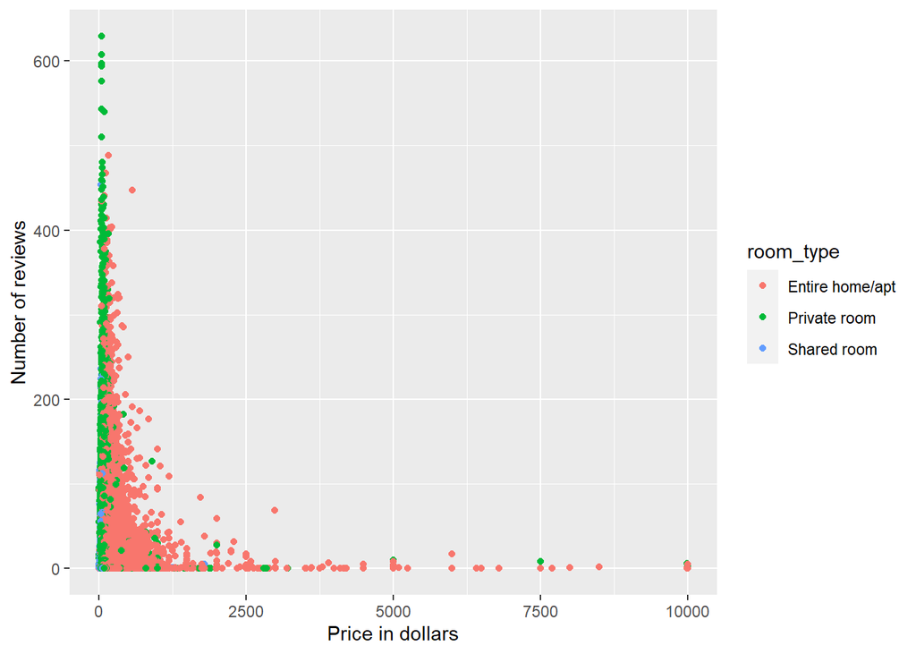

```r
ggplot(data = airbnb1) +
  geom_point(mapping = aes(x = price, y = number_of_reviews, color = room_type)) +
  labs(x = "Price in dollars", y = "Number of reviews") # Add label
```

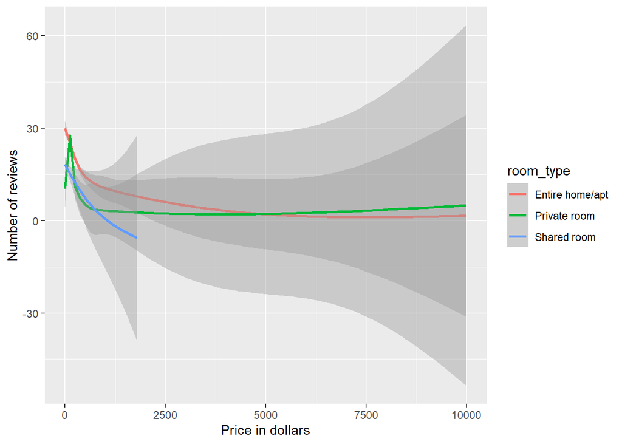

```r
ggplot(data = airbnb1) +
  geom_smooth(mapping = aes(x = price, y = number_of_reviews, color = room_type)) +
  labs(x = "Price in dollars", y = "Number of reviews") # Add label
```

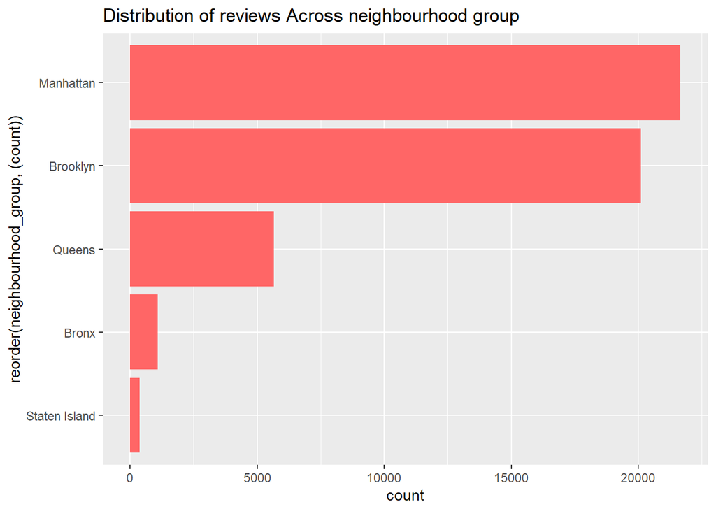

```r
library(dplyr)


airbnb1 %>%
    group_by(neighbourhood_group) %>%  #group by state.of.res.
    summarise(count = n()) %>%  #Count observations by group
   ggplot(aes(x = reorder(neighbourhood_group,(count)), y = count)) +  #reorder the x and y, note that (-count) for ascending order
      geom_bar(stat = 'identity',fill = "#FF6666")+   #the heights of the bars represent values in the data, use stat="identity" and map a value to the y aesthetic."
     coord_flip()+     # flip x and y and shown in descending order
      ggtitle("Distribution of reviews Across neighbourhood group") # Add title
```

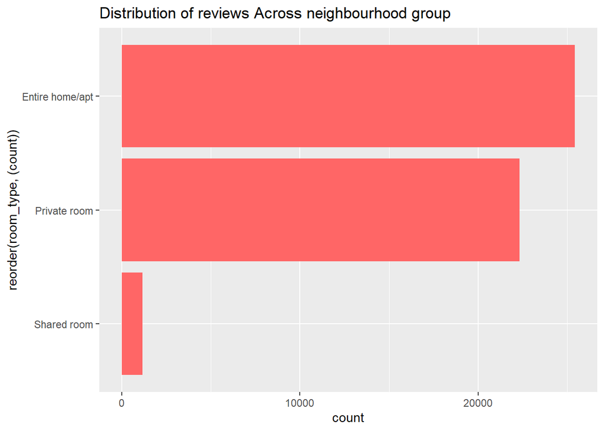

```r
library(dplyr)


airbnb1 %>%
    group_by(room_type) %>%  #group by room_type
    summarise(count = n()) %>%  #Count observations by group
   ggplot(aes(x = reorder(room_type,(count)), y = count)) +  #reorder the x and y, note that (-count) for ascending order
      geom_bar(stat = 'identity',fill = "#FF6666")+   #the heights of the bars represent values in the data, use stat="identity" and map a value to the y aesthetic."
     coord_flip()+     # flip x and y and shown in descending order
      ggtitle("Distribution of reviews Across neighbourhood group") # Add title
```

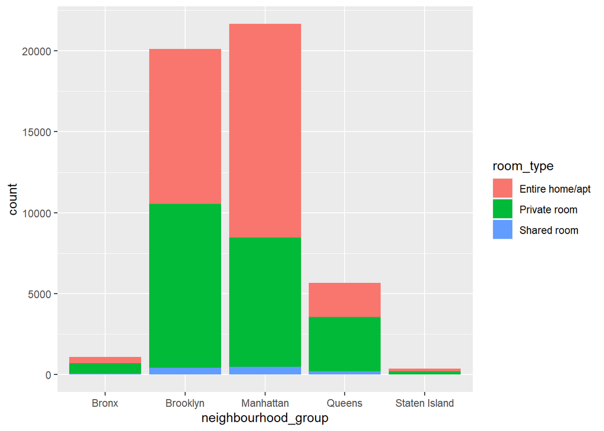

```r
ggplot(data = airbnb1) +
  geom_bar(mapping = aes(x = neighbourhood_group, fill=room_type))
```

Manhattan has the largest number of entire home/apt than other neighbourhood groups, and Brooklyn has the largest number of private room than other groups.

Here, we only consider reviews under 60.

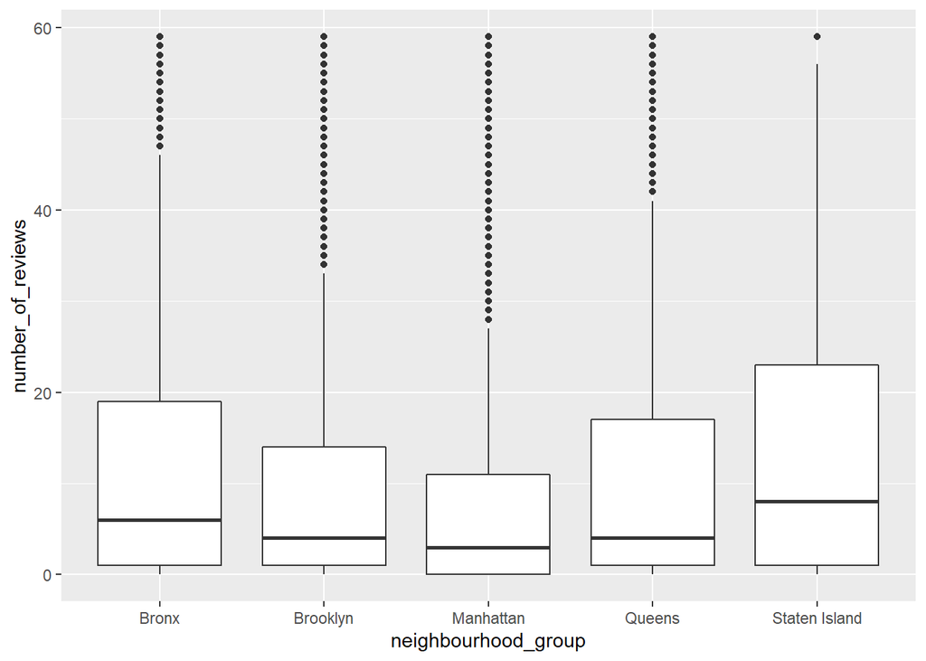

```r
airbnb1 %>%
  filter(number_of_reviews < 60) %>%
ggplot(aes(x = neighbourhood_group, y = number_of_reviews)) +
  geom_boxplot()
```

On average, Stataen Island has the most reviews when only consider number of reviews < 60.

Plot two side-by-side box plots. It’s hard to see the average line.

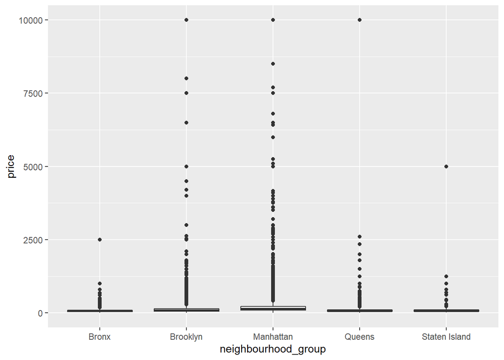

```r
#airbnb1 %>%
  #filter(ggplot()+
ggplot(data = airbnb1,mapping = aes(x = neighbourhood_group, y = price)) +
  geom_boxplot()
```

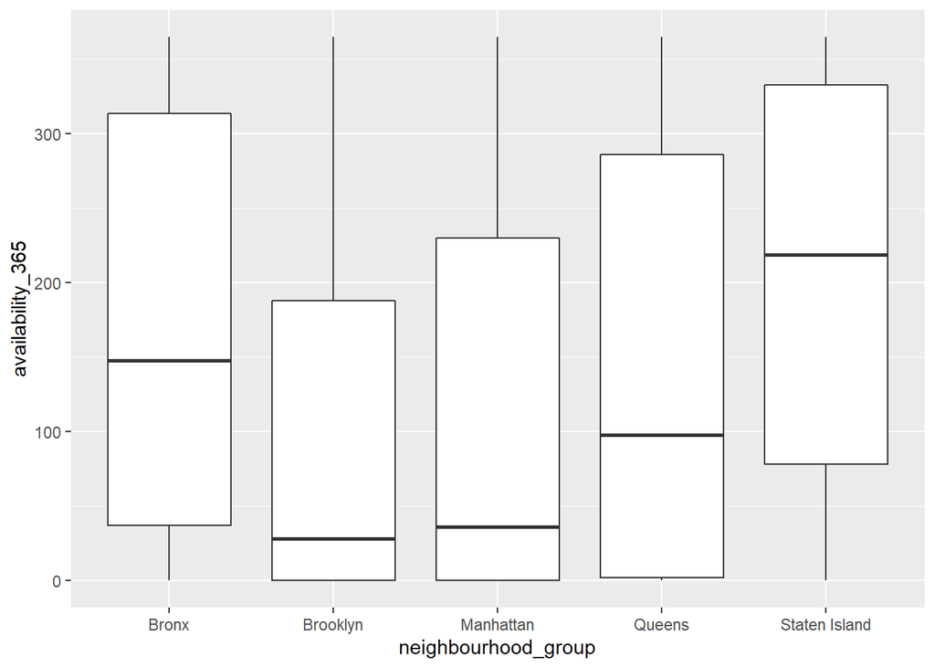

```r
ggplot(data = airbnb1, mapping = aes(x = neighbourhood_group, y = availability_365)) +
  geom_boxplot()
```

On average, Staten Island are the most available throughout the year, while Brooklyn and Manhattan are the least available.

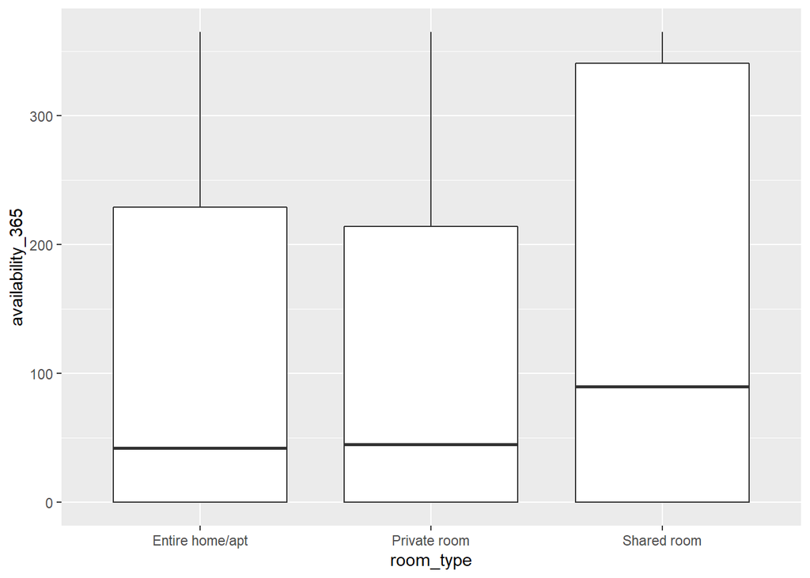

```r
ggplot(data = airbnb1, mapping = aes(x = room_type, y = availability_365)) +
  geom_boxplot()
```

Shared room is more available than entire home and private room.

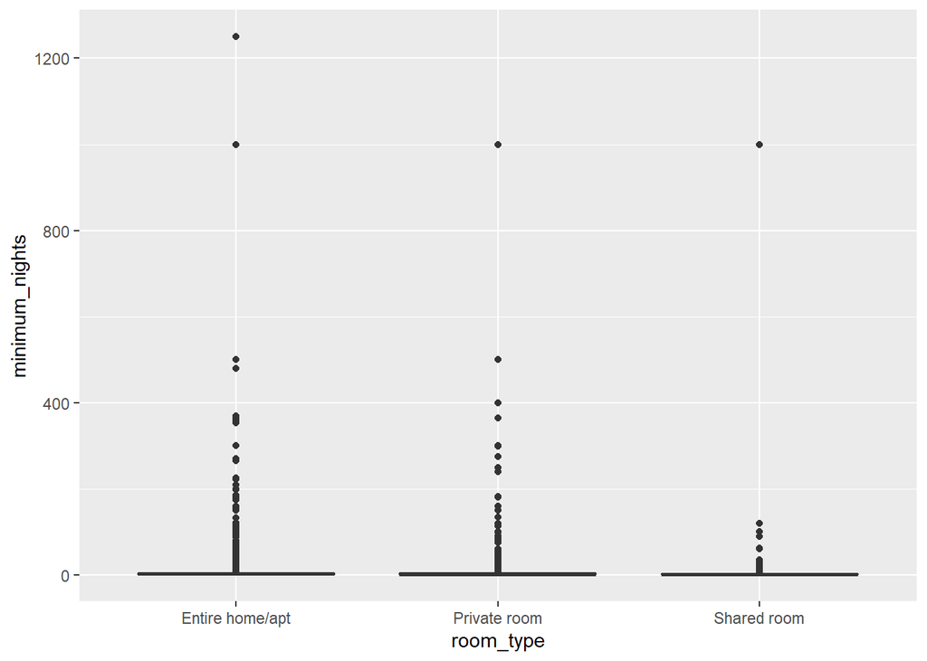

```r
ggplot(data = airbnb1, mapping = aes(x = room_type, y = minimum_nights)) +
  geom_boxplot()
```

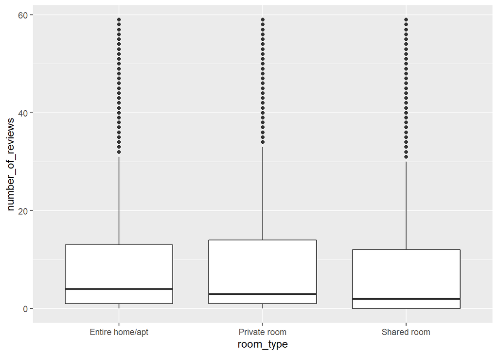

```r
airbnb1 %>%
  filter(number_of_reviews < 60) %>%
ggplot(aes(x = room_type, y = number_of_reviews)) +
  geom_boxplot()
```

When only considering number_of_reviews < 60, entire home has the most reviews than other two types, but the difference is small.

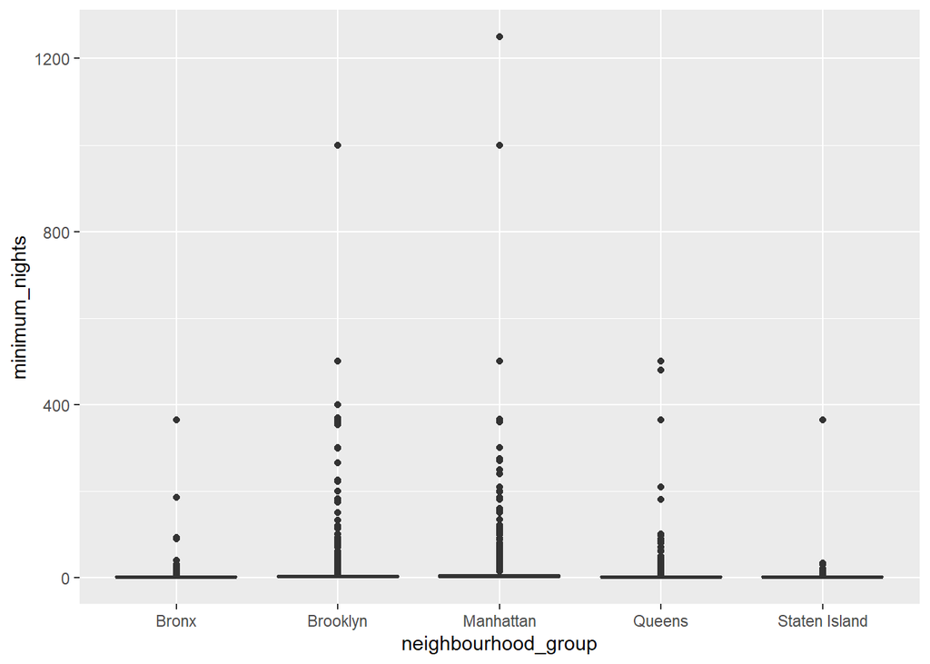

```r
ggplot(data = airbnb1, mapping = aes(x = neighbourhood_group, y = minimum_nights)) +
  geom_boxplot()
```

The trend is more clear when we put a filter = number_of_reviews < 60.

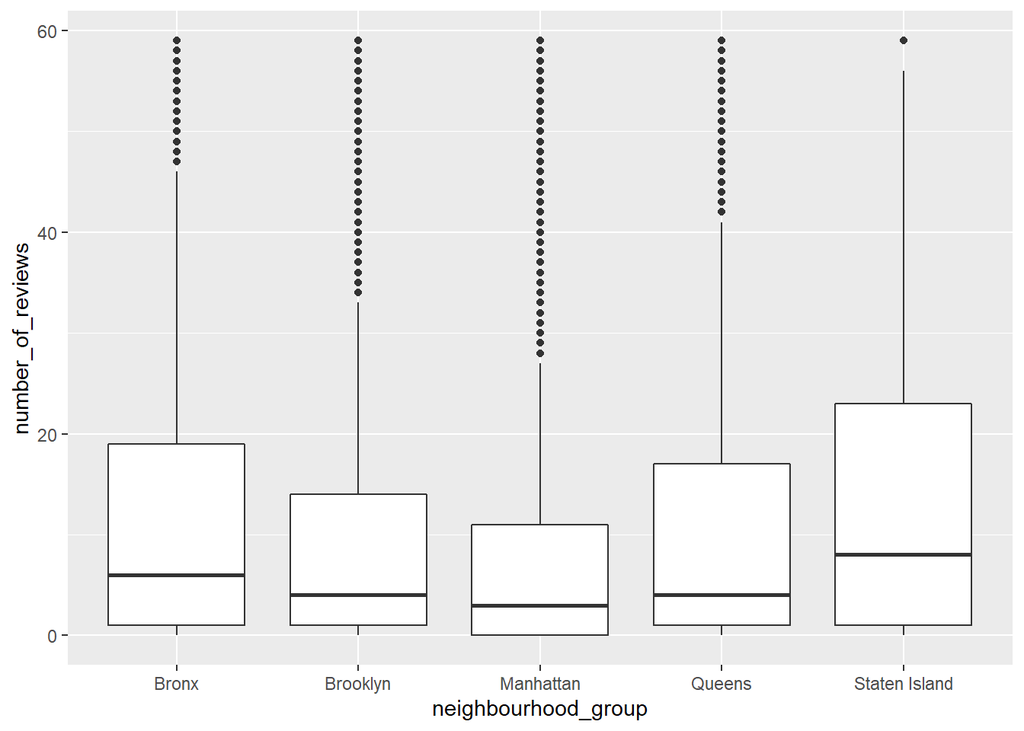

```r
airbnb1 %>%
  filter(number_of_reviews < 60) %>%
ggplot(aes(x = neighbourhood_group, y = number_of_reviews)) +
  geom_boxplot()
```

When only considering number_of_reviews < 60, Staten island has the most reviews on average than other groups.

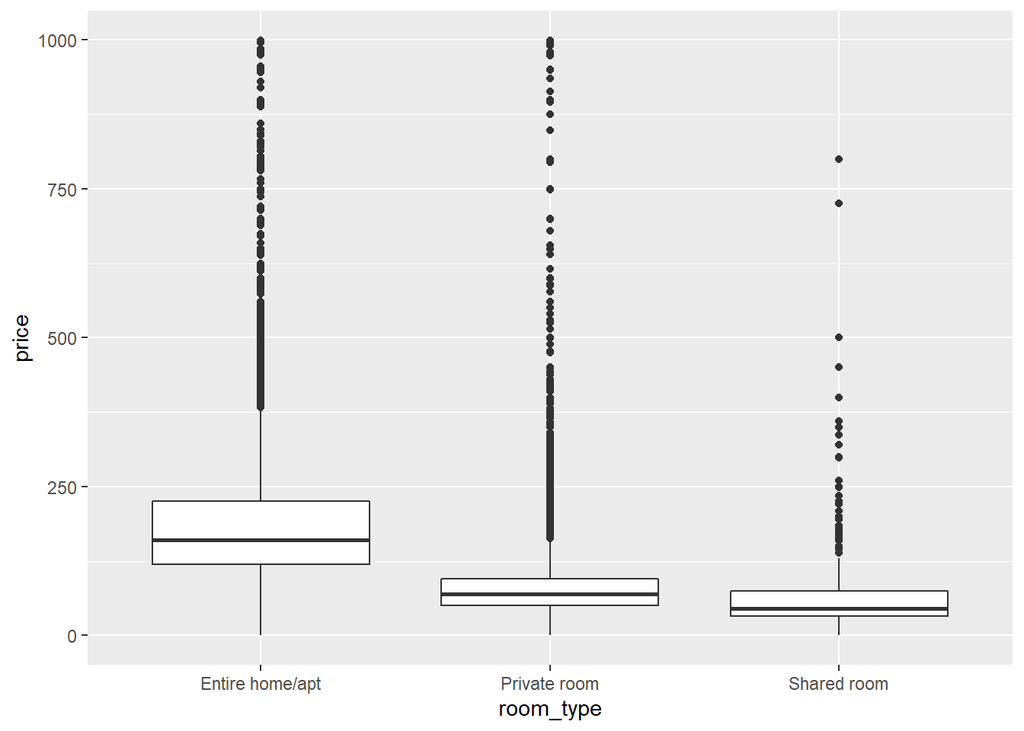

```r
library(ggplot2)
airbnb1 %>%
  filter(price < 1000) %>%
ggplot(aes(x = room_type, y = price)) +
  geom_boxplot()
```

When only considering price < 1000, entire home is more expensive than other two types.

Since price is highly skewed, we try to cut price into different levels based on 5 number summary statistics.

```r
sum( airbnb1$price> 174)
```

```
## [1] 12940
```

```r
#hist(airbnb1$price, breaks = 100)
```

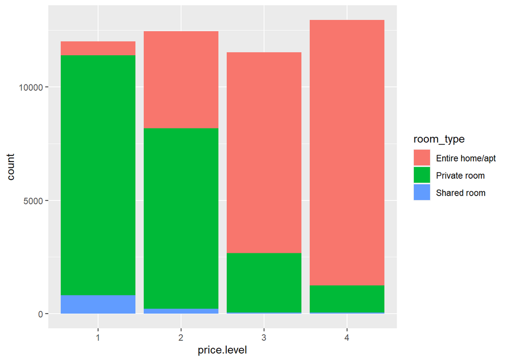

```r
library(dplyr)

airbnb1 <- airbnb1 %>% mutate(price.level = case_when(price < 69 ~ '1',
                                             price > 68  & price < 106 ~ '2',
                                           price > 105  & price <175 ~ '3',
                                           price > 174 ~ '4')) # end function
#view(airbnb1)

ggplot(data = airbnb1) +
  geom_bar(mapping = aes(x = price.level, fill=room_type))
```

Entire room demands higher price, while shared room is usually cheaper.

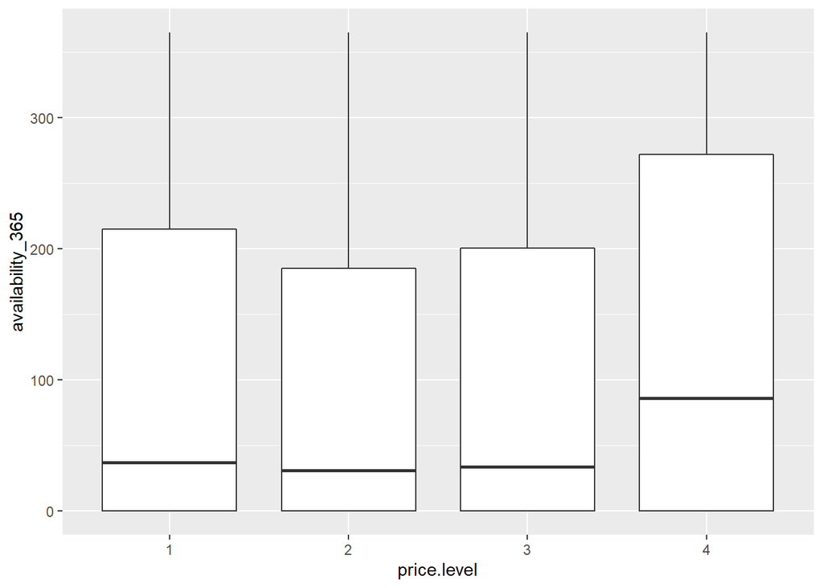

```r
ggplot(data = airbnb1, mapping = aes(x = price.level, y = availability_365)) +
  geom_boxplot()
```

On average, most expensive listings are more available.

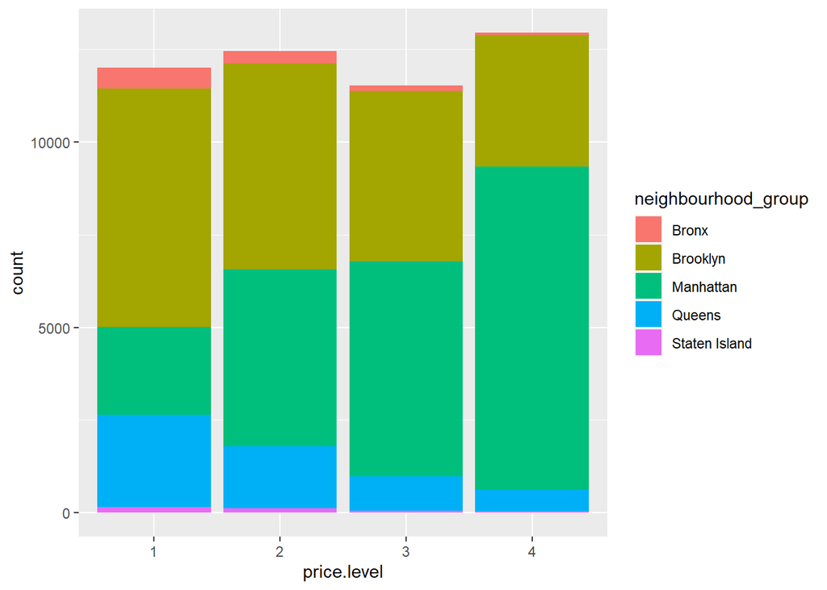

```r
ggplot(data = airbnb1) +
  geom_bar(mapping = aes(x = price.level, fill=neighbourhood_group))
```

Most expensive listings are located in Manhattan, and Brooklyn has the most cheapest listings.

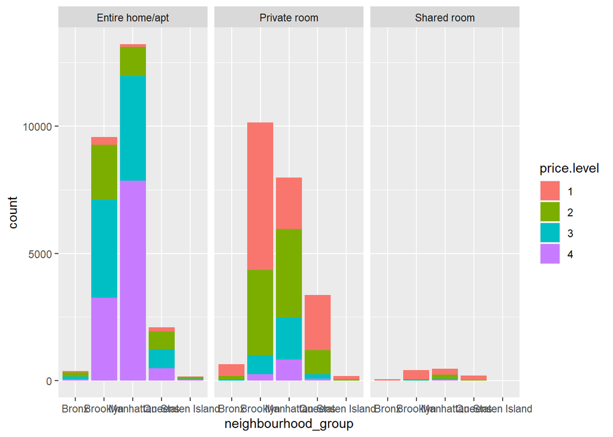

```r
base1<-ggplot(data=airbnb1, aes(x=neighbourhood_group, fill=price.level)) +
  geom_bar()

base1+facet_wrap(~ room_type)
```

Manhattan has the largest number of level 4 listings regardless of the room types, while Brooklyn has the largest number of level 1 listings across all room types.

```r
#We found some qualitative features.
col.qli<-names(airbnb1)%in%c("id","name", "host_id","host_name", "neighbourhood_group", "neighbourhood", "room_type", "last_review", "price.level", "calculated_host_listings_count")

lapply(airbnb1[,!col.qli],range)
```

```
## $latitude
## [1] 40.49979 40.91306
##
## $longitude
## [1] -74.24442 -73.71299
##
## $price
## [1]     0 10000
##
## $minimum_nights
## [1]    1 1250
##
## $number_of_reviews
## [1]   0 629
##
## $availability_365
## [1]   0 365
```

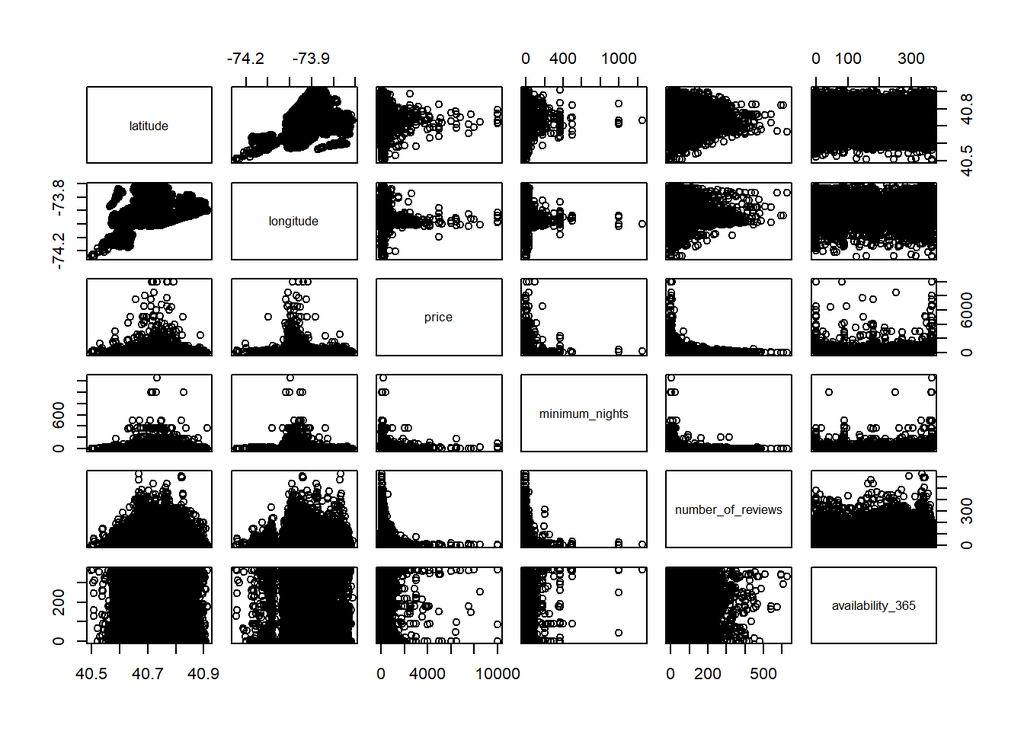

```r
pairs(airbnb1[,!col.qli])
```

[figure not shown]

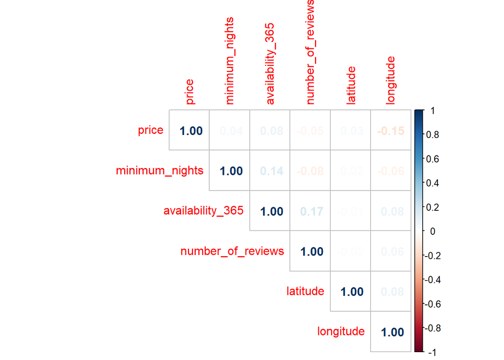

```r
library(corrplot)
#install.packages("corrgram")
library(corrgram)
quanti<-airbnb1[,!col.qli]
corrplot(corrgram(quanti), method = 'number', order = 'AOE', type = 'upper')
```

We found that the correlations between each pair of predictors are weak.

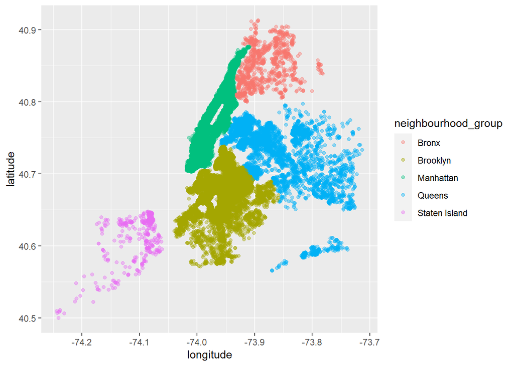

```r
airbnb1 %>%
  ggplot(aes(x = longitude, y = latitude, color= neighbourhood_group)) +
  geom_point(alpha = 0.4)
```

we further filter the price to be less than $450, just to show the trend more clearly.

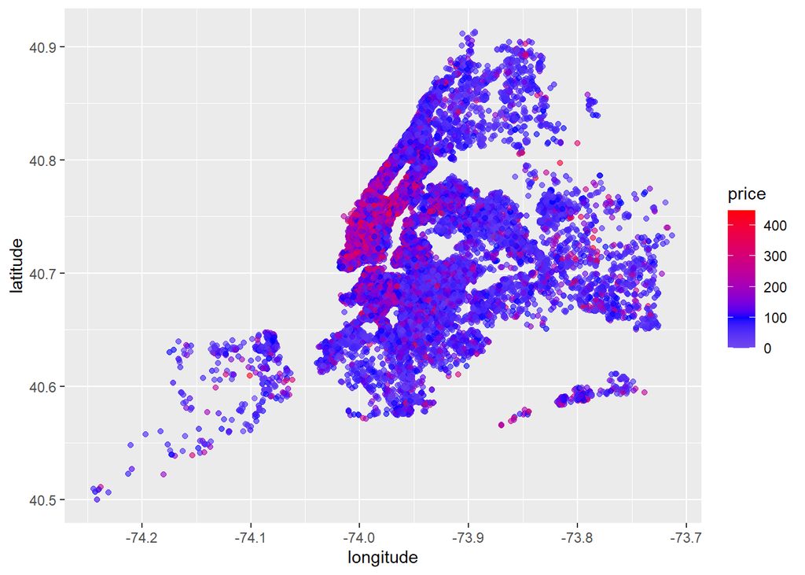

```r
airbnb1 %>%
  filter(price < 450) %>% # choose a cut off point
  ggplot(aes(x = longitude, y = latitude, color= price)) +
  geom_point(alpha = 0.6) +
  scale_colour_gradient2(low = "grey", mid = "blue", high = "red", midpoint = 100)
```

Obviously, Manhattan owns more expensive airbnbs.

#### Part 2 Modelling

1. Regression Analysis

```r
#install.packages("car")
#install.packages("gvlma")
#install.packages("MASS")
#install.packages("leaps")
#install.packages("effects")

library(car) # car: Companion to Applied Regression. The name of this package is very confusing. The package has nothing to do with "cars". It contains many usefuld function and datasets.
library(gvlma)
library(MASS)
library(leaps)
library(effects)
```

#### Regression Diagnostics

```r
#checking confidence interval
airbnb2 <- as.data.frame(airbnb1[,c("price", "neighbourhood_group", "latitude", "longitude", "room_type","minimum_nights", "number_of_reviews","availability_365")])
fit <- lm(price ~., data=airbnb2)
summary(fit)
```

```
##
## Call:
## lm(formula = price ~ ., data = airbnb2)
##
## Residuals:
##    Min     1Q Median     3Q    Max
## -251.5  -62.5  -23.7   15.6 9947.8
##
## Coefficients:
##                                    Estimate Std. Error t value Pr(>|t|)
## (Intercept)                      -2.848e+04  3.205e+03  -8.885  < 2e-16 ***
## neighbourhood_groupBrooklyn      -3.040e+01  8.762e+00  -3.470 0.000521 ***
## neighbourhood_groupManhattan      2.887e+01  7.955e+00   3.629 0.000284 ***
## neighbourhood_groupQueens        -3.199e+00  8.446e+00  -0.379 0.704846
## neighbourhood_groupStaten Island -1.465e+02  1.666e+01  -8.791  < 2e-16 ***
## latitude                         -1.917e+02  3.128e+01  -6.130 8.86e-10 ***
## longitude                        -4.933e+02  3.593e+01 -13.730  < 2e-16 ***
## room_typePrivate room            -1.053e+02  2.156e+00 -48.846  < 2e-16 ***
## room_typeShared room             -1.411e+02  6.880e+00 -20.504  < 2e-16 ***
## minimum_nights                   -5.389e-02  5.143e-02  -1.048 0.294770
## number_of_reviews                -2.926e-01  2.370e-02 -12.346  < 2e-16 ***
## availability_365                  1.839e-01  8.206e-03  22.415  < 2e-16 ***
## ---
## Signif. codes:  0 '***' 0.001 '**' 0.01 '*' 0.05 '.' 0.1 ' ' 1
##
## Residual standard error: 228.1 on 48883 degrees of freedom
## Multiple R-squared:  0.09769,    Adjusted R-squared:  0.09749
## F-statistic: 481.1 on 11 and 48883 DF,  p-value: < 2.2e-16
```

```r
confint(fit)
```

```
##                                          2.5 %        97.5 %
## (Intercept)                      -3.475966e+04 -2.219542e+04
## neighbourhood_groupBrooklyn      -4.757512e+01 -1.322954e+01
## neighbourhood_groupManhattan      1.328087e+01  4.446640e+01
## neighbourhood_groupQueens        -1.975443e+01  1.335563e+01
## neighbourhood_groupStaten Island -1.791137e+02 -1.138029e+02
## latitude                         -2.530233e+02 -1.304179e+02
## longitude                        -5.636794e+02 -4.228480e+02
## room_typePrivate room            -1.095581e+02 -1.011049e+02
## room_typeShared room             -1.545391e+02 -1.275712e+02
## minimum_nights                   -1.546898e-01  4.691944e-02
## number_of_reviews                -3.390257e-01 -2.461311e-01
## availability_365                  1.678521e-01  2.000190e-01
```

The results suggest that variable “minimum_nights” might not be statistically significant.

Let’s see the evaluation of this model by plot() function.

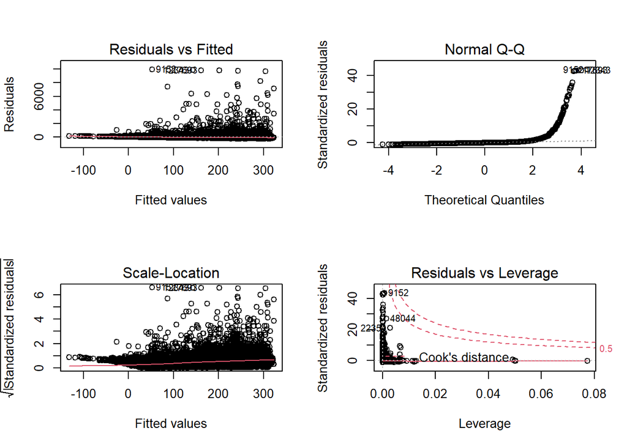

```r
#checking diagnostic plots
par(mfrow=c(2,2)) # Show plots in 2x2 grid.
plot(fit)
```

```r
summary(fit)
```

```
##
## Call:
## lm(formula = price ~ ., data = airbnb2)
##
## Residuals:
##    Min     1Q Median     3Q    Max
## -251.5  -62.5  -23.7   15.6 9947.8
##
## Coefficients:
##                                    Estimate Std. Error t value Pr(>|t|)
## (Intercept)                      -2.848e+04  3.205e+03  -8.885  < 2e-16 ***
## neighbourhood_groupBrooklyn      -3.040e+01  8.762e+00  -3.470 0.000521 ***
## neighbourhood_groupManhattan      2.887e+01  7.955e+00   3.629 0.000284 ***
## neighbourhood_groupQueens        -3.199e+00  8.446e+00  -0.379 0.704846
## neighbourhood_groupStaten Island -1.465e+02  1.666e+01  -8.791  < 2e-16 ***
## latitude                         -1.917e+02  3.128e+01  -6.130 8.86e-10 ***
## longitude                        -4.933e+02  3.593e+01 -13.730  < 2e-16 ***
## room_typePrivate room            -1.053e+02  2.156e+00 -48.846  < 2e-16 ***
## room_typeShared room             -1.411e+02  6.880e+00 -20.504  < 2e-16 ***
## minimum_nights                   -5.389e-02  5.143e-02  -1.048 0.294770
## number_of_reviews                -2.926e-01  2.370e-02 -12.346  < 2e-16 ***
## availability_365                  1.839e-01  8.206e-03  22.415  < 2e-16 ***
## ---
## Signif. codes:  0 '***' 0.001 '**' 0.01 '*' 0.05 '.' 0.1 ' ' 1
##
## Residual standard error: 228.1 on 48883 degrees of freedom
## Multiple R-squared:  0.09769,    Adjusted R-squared:  0.09749
## F-statistic: 481.1 on 11 and 48883 DF,  p-value: < 2.2e-16
```

In the residuals plot, more data points are dispersed over 0 than below 0, but no obvious pattern is found. The QQ plot is “skewed right,” meaning that most of the data is distributed on the left side with a long “tail” of data extending out to the right. Thus, the normaility assumption of OLS regression is NOT met. Also, data points #9152, #48044, and #2235 seem to be outliers according to the residuals vs. leverage plot.

#### An enhanced/advanced approach

##### Assessing normality

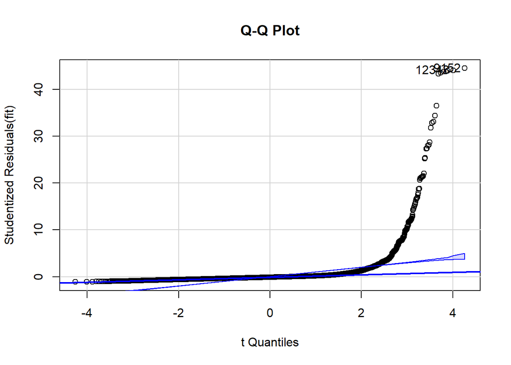

```
## [1]  9152 12343
```

```r
fit <- lm(price ~., data=airbnb2)
qqPlot(fit, labels=row.names(airbnb2), id.method="identify",
       simulate=TRUE, main="Q-Q Plot")
```

The QQ plot is curved, not a straight line, which violates the normality assumption.

##### Assessing linearity

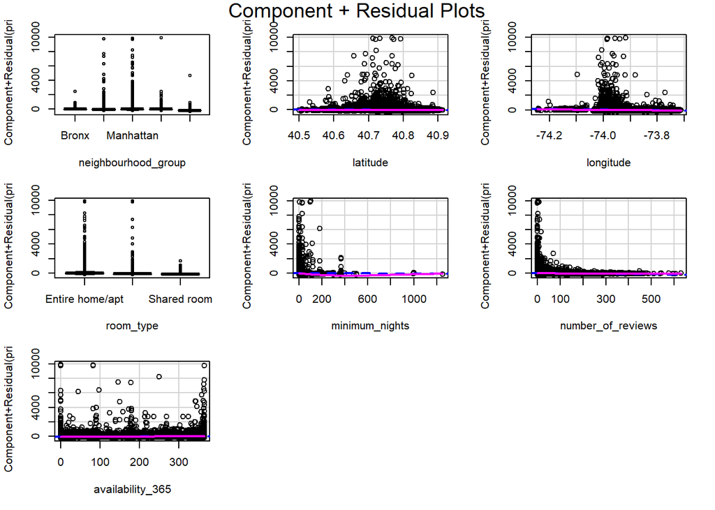

```r
crPlots(fit)
```

The solid-line is the smoothened plot. We cannot identify nonlinearity in any of these plots.

##### Assessing homoscedasticity

The car package also provides two useful functions for identifying non-constant error variance. The ncvTest() function produces a score test of the hypothesis of constant error variance against the alternative that the error variance changes with the level of the fitted values. A significant result suggests heteroscedasticity (nonconstant error variance).

Visualt Test: The spreadLevelPlot() function creates a scatter plot of the absolute standardized residuals versus the fitted values, and superimposes a line of best fit.

```r
ncvTest(fit)
```

```
## Non-constant Variance Score Test
## Variance formula: ~ fitted.values
## Chisquare = 16606.23, Df = 1, p = < 2.22e-16
```

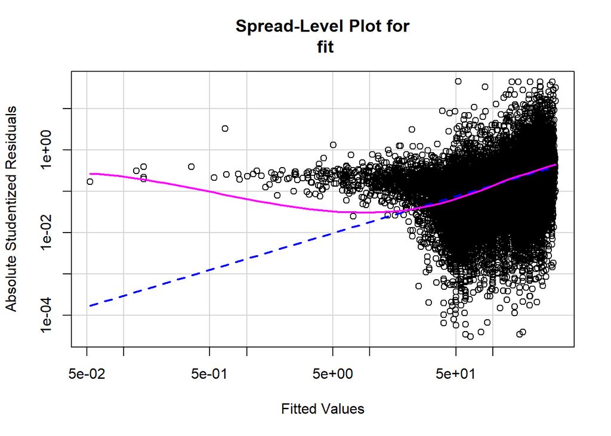

```
##
## Suggested power transformation:  0.1097962
```

```r
spreadLevelPlot(fit)
```

```r
summary(fit)
```

```
##
## Call:
## lm(formula = price ~ ., data = airbnb2)
##
## Residuals:
##    Min     1Q Median     3Q    Max
## -251.5  -62.5  -23.7   15.6 9947.8
##
## Coefficients:
##                                    Estimate Std. Error t value Pr(>|t|)
## (Intercept)                      -2.848e+04  3.205e+03  -8.885  < 2e-16 ***
## neighbourhood_groupBrooklyn      -3.040e+01  8.762e+00  -3.470 0.000521 ***
## neighbourhood_groupManhattan      2.887e+01  7.955e+00   3.629 0.000284 ***
## neighbourhood_groupQueens        -3.199e+00  8.446e+00  -0.379 0.704846
## neighbourhood_groupStaten Island -1.465e+02  1.666e+01  -8.791  < 2e-16 ***
## latitude                         -1.917e+02  3.128e+01  -6.130 8.86e-10 ***
## longitude                        -4.933e+02  3.593e+01 -13.730  < 2e-16 ***
## room_typePrivate room            -1.053e+02  2.156e+00 -48.846  < 2e-16 ***
## room_typeShared room             -1.411e+02  6.880e+00 -20.504  < 2e-16 ***
## minimum_nights                   -5.389e-02  5.143e-02  -1.048 0.294770
## number_of_reviews                -2.926e-01  2.370e-02 -12.346  < 2e-16 ***
## availability_365                  1.839e-01  8.206e-03  22.415  < 2e-16 ***
## ---
## Signif. codes:  0 '***' 0.001 '**' 0.01 '*' 0.05 '.' 0.1 ' ' 1
##
## Residual standard error: 228.1 on 48883 degrees of freedom
## Multiple R-squared:  0.09769,    Adjusted R-squared:  0.09749
## F-statistic: 481.1 on 11 and 48883 DF,  p-value: < 2.2e-16
```

Here, the null hypothesis is H0 = constant error variance, and the alternative hypothesis is Ha = Non-constant error variance, and alpha = 0.05.

The p-value <0.05 suggest that we reject the null and conclude that the variance is non-constant, which violates the OLS assumption.

##### Global test of linear model assumptions

```r
library(gvlma)
gvmodel <- gvlma(fit)
summary(gvmodel)
```

```
##
## Call:
## lm(formula = price ~ ., data = airbnb2)
##
## Residuals:
##    Min     1Q Median     3Q    Max
## -251.5  -62.5  -23.7   15.6 9947.8
##
## Coefficients:
##                                    Estimate Std. Error t value Pr(>|t|)
## (Intercept)                      -2.848e+04  3.205e+03  -8.885  < 2e-16 ***
## neighbourhood_groupBrooklyn      -3.040e+01  8.762e+00  -3.470 0.000521 ***
## neighbourhood_groupManhattan      2.887e+01  7.955e+00   3.629 0.000284 ***
## neighbourhood_groupQueens        -3.199e+00  8.446e+00  -0.379 0.704846
## neighbourhood_groupStaten Island -1.465e+02  1.666e+01  -8.791  < 2e-16 ***
## latitude                         -1.917e+02  3.128e+01  -6.130 8.86e-10 ***
## longitude                        -4.933e+02  3.593e+01 -13.730  < 2e-16 ***
## room_typePrivate room            -1.053e+02  2.156e+00 -48.846  < 2e-16 ***
## room_typeShared room             -1.411e+02  6.880e+00 -20.504  < 2e-16 ***
## minimum_nights                   -5.389e-02  5.143e-02  -1.048 0.294770
## number_of_reviews                -2.926e-01  2.370e-02 -12.346  < 2e-16 ***
## availability_365                  1.839e-01  8.206e-03  22.415  < 2e-16 ***
## ---
## Signif. codes:  0 '***' 0.001 '**' 0.01 '*' 0.05 '.' 0.1 ' ' 1
##
## Residual standard error: 228.1 on 48883 degrees of freedom
## Multiple R-squared:  0.09769,    Adjusted R-squared:  0.09749
## F-statistic: 481.1 on 11 and 48883 DF,  p-value: < 2.2e-16
##
##
## ASSESSMENT OF THE LINEAR MODEL ASSUMPTIONS
## USING THE GLOBAL TEST ON 4 DEGREES-OF-FREEDOM:
## Level of Significance =  0.05
##
## Call:
##  gvlma(x = fit)
##
##                        Value p-value                   Decision
## Global Stat        9.949e+08  0.0000 Assumptions NOT satisfied!
## Skewness           3.754e+06  0.0000 Assumptions NOT satisfied!
## Kurtosis           9.912e+08  0.0000 Assumptions NOT satisfied!
## Link Function      3.312e+02  0.0000 Assumptions NOT satisfied!
## Heteroscedasticity 2.513e-02  0.8741    Assumptions acceptable.
```

We can see that all the stats are suggesting that *Assumptions are not satisfied* except heteroscedasticity (non-constant variance). It means that we have violated the assumptions of linear regression.